# How to Make a Free Throw Shooter Miss

Kevin Toney

March 23, 2016

# Research Question & Background

# Questions

- What factors influence a player’s free throw percentage for good or for bad?
- What makes a free throw shooter miss?
- Does crowd noise make a difference?

# What we did to find out!

- We asked 20 people to shoot 20 free throws.
- Before they shot the free throws, we separated them, with the help of a random number generator, into four different groups. Each group represented a different situation. Each situation is shown in the table below.

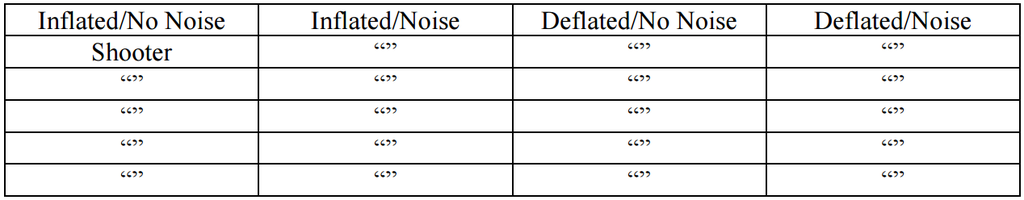

# Experimental Design

# Statistical Model

# Experimental Design

- 2x2 Basic Factorial Design
- Factor 1: Crowd Noise
- Factor 2: Inflation Level
- Control: Shooting free throws without noise and with an inflated ball

# Results

# The Experiment’s Results

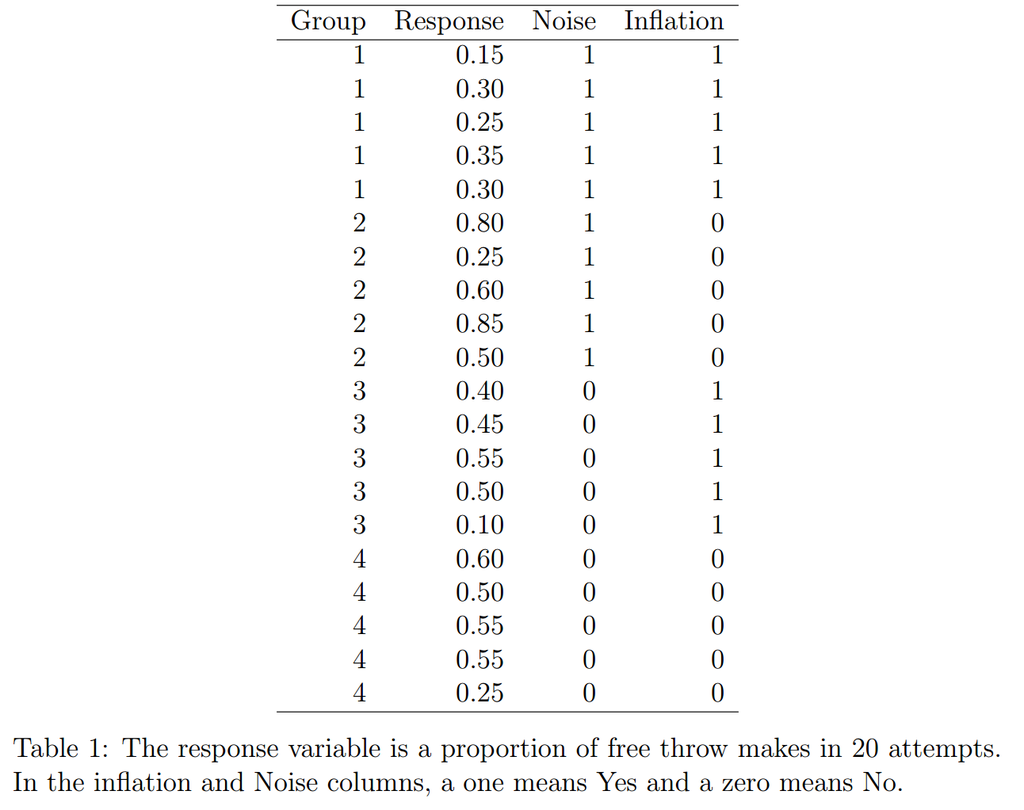

Data table for the results

# Precautions against confounding variables

- I put the data into a binomial distribution to make each shooter independent of each other.

# Analysis

# Notes for Reference

- The variances of each group are not similar. In order to run and ANOVA regression model, we made a log transformation to the data so the data had variances that were more alike.
- We found an interaction between noise and inflation.

# The Interaction Plots

[figure not shown]

The interaction plots for the two factors

# Method of Analysis

- We performed a poisson regression model to compare the average amount of shots made per player.
- In poisson regression, the null deviance is the base model. If we do regression for all three factors, the degrees of freedom is 16.

# Significant Findings

```r
pois_diff <- 35.945 - 22.174
1 - pchisq(pois_diff, df = 3)
```

```
## [1] 0.003234027
```

```r
pois_diff_2 <- 35.945 - 25.802
1 - pchisq(pois_diff_2, df = 2)
```

```
## [1] 0.006273004
```

```r
pois_diff_3 <- 25.825 - 25.802
1 - pchisq(pois_diff_3, df = 1)
```

```
## [1] 0.8794571
```

```r
pois_diff_4 <- 35.922 - 25.802
1 - pchisq(pois_diff_4, df = 1)
```

```
## [1] 0.00146669
```

# Conclusions

# So what?

- Now, do these statistically significant factors have a practical significance? The predict.glm function will help us determine statistical significance.

```
##        1        2        3        4        5        6        7        8
## 1.686399 1.686399 1.686399 1.686399 1.686399 2.484907 2.484907 2.484907
##        9       10       11       12       13       14       15       16
## 2.484907 2.484907 2.079442 2.079442 2.079442 2.079442 2.079442 2.282382
##       17       18       19       20
## 2.282382 2.282382 2.282382 2.282382
```

# Conclusion